# SIG Project Real-Time Imputation

Steven Nijman*, Hanne Oberman*, Gerko Vink, Thomas Debray, Maarten van Smeden

Simulation pipeline organized according to the ADEMP approach: Aims, Data-generating mechanisms, Methods, Estimands, Performance measures.

TODO:

- Check where else it says “TODO” and “Add” throughout this file
- Add motivating example with MIMIC data (first impute once with some non-parametric model like an AE, then fit some prediction model on the completed population data)
- Choose a nice logistic prediction model for the motivating example, like a certain diagnosis or 48h mortality (not 30 day mortality, because then you need time-to-event models)
- Rename mean imp to CMI
- Rename ‘true’ model to spline model
- Add rf model after imputation
- Rerun sim without higher order terms
- After running the simulation, check convergence of the population diagnostics to see if 1000 repetitions was enough

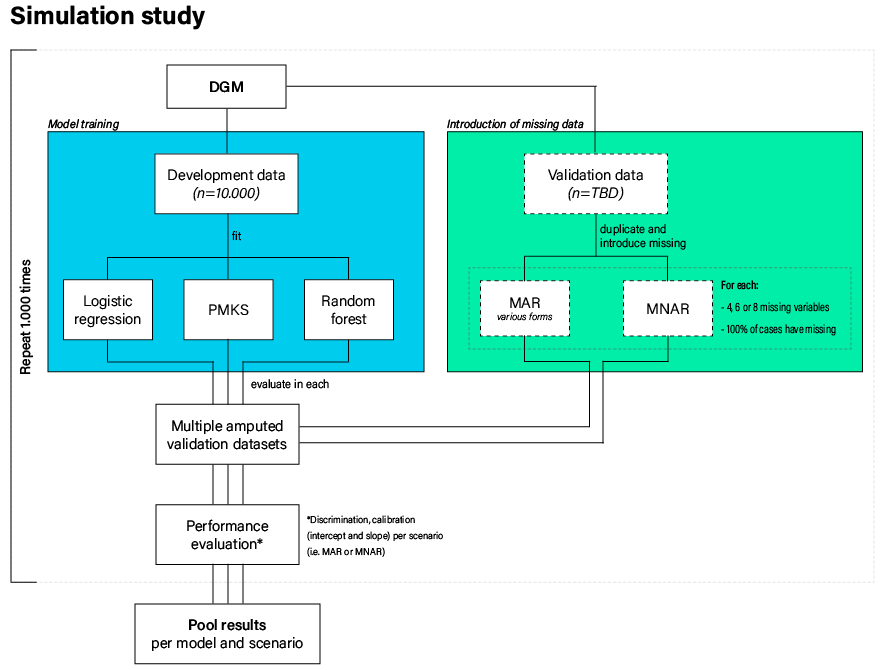

# 1 Aims

This document contain the set-up of our SIG project titled “An evaluation of ‘real-time’ missing data handling in machine learning and prevailing statistical models”. The aim is to compare different strategies for developing prediction models that can handle the presence of missing values real time in a single patient. Preferred journal: Stat. Med.

# 2 Data-Generating Mechanisms

We use model-based simulation, with a single data-generating mechanism for the development data and validation sets. The development set is used as-is; the validation set is subsequently ‘amputed’.

## 2.1 DGM model

We use a DGM model with:

- 10 continuous predictors ($X_1$, $X_2$, …, $X_{10}$), with cases generated from a multivariate normal distribution;[^1]
- 1 binary outcome ($Y$), calculated from the 10 predictors.

We decided against the use of a ‘real world’ variance-covariance matrix for the predictor variables. Initially, we were going to use the SMART data as the basis for our predictor space. But this would result in the same limitations as described in Nijman et al. (2021; i.e., low correlations between predictor variables).

Therefore, we randomly generated a variance-covariance matrix for the purpose of this study. This matrix[^2] serves as the basis for each development and/or validation dataset used in this study.

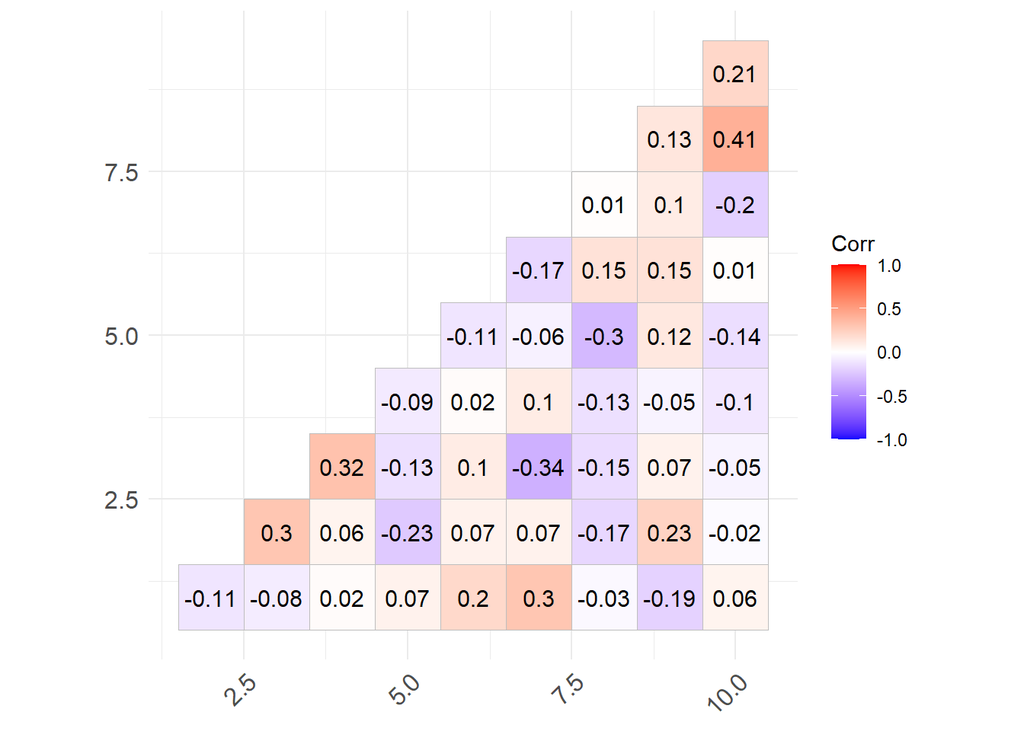

```r
# create a variance-covariance matrix with p predictors
varcov <- define_varcov(p = 10)
ggcorrplot::ggcorrplot(cov2cor(varcov), type = "lower", lab = TRUE)
```

```r
# create vectors with regression coefficients for linear and non-linear effects
linear_betas <- runif(nrow(varcov), -1, 1)
non_linear_betas <- runif(nrow(varcov), -0.1, 0.1)
```

We use the 10 predictors to calculate the dichotomous outcome. The current DGM model includes one cubic term and 9 interactions. For additional complexity, we add one log-transformation (the natural logarithm of the absolute value of the second predictor).

TODO: check c-stat [.6-.9] TODO: report the betas

## 2.2 Development set

We use a sample size of 10.000 in the development sets. One such set is generated below.

```r
# let's generate some data
devset <-
  generate_sample(
    sample_size = 10000,
    covariance_matrix = varcov,
    linear_bs = linear_betas,
    non_linear_bs = non_linear_betas,
    interaction = TRUE
  )

# what do the data look like?
glimpse(devset)
```

```
## Rows: 10,000
## Columns: 12
## $ Y_prob <dbl> 0.0317537744, 0.0133542165, 0.0128994242, 0.0016731205, 0.62407~
## $ Y      <int> 0, 0, 0, 0, 1, 0, 0, 0, 0, 0, 1, 0, 1, 1, 0, 0, 0, 0, 0, 0, 0, ~
## $ X1     <dbl> 1.621176952, -0.073868460, 1.056586279, 0.672178494, -0.8559389~
## $ X2     <dbl> -1.66657558, -0.12844528, -0.37303698, 0.94793425, 2.56152106, ~
## $ X3     <dbl> 0.44235649, 0.48518893, -1.26237273, 0.30986259, 1.87072996, -1~
## $ X4     <dbl> 0.26579630, 0.66477932, 0.02131023, -0.28467731, 0.16897745, -0~
## $ X5     <dbl> 0.47822295, 1.91377683, 0.13714976, 0.73782965, -1.32161078, 1.~
## $ X6     <dbl> 0.480902686, -0.256503954, 0.070834560, 0.901573003, -0.6481446~
## $ X7     <dbl> -0.41865161, -2.17863061, 0.88825519, 0.17334088, 0.15304982, 0~
## $ X8     <dbl> -0.572644578, 0.271221800, -0.259781620, 0.257371730, -0.667793~
## $ X9     <dbl> -1.50509570, -0.77567963, 0.40210671, -0.08403530, -0.19775433,~
## $ X10    <dbl> -1.15544434, -0.41822045, -0.17324444, 1.17739766, -1.07825203,~
```

The aim is to have a prevalence of about 0.15. In this dev set, the prevalence of the outcome is 0.1605. We can now fit the different models.

```r
# logistic model
mod_true <- fit_true(devset[,-1])

# box of submodels
mod_sub_6 <- fit_sub(devset[,-1], Y ~ X1 + X2 + X3 + X4 + X5 + X6)
mod_sub_4 <- fit_sub(devset[,-1], Y ~ X1 + X2 + X3 + X4)
mod_sub_2 <- fit_sub(devset[,-1], Y ~ X1 + X2)

# random forest models with imputation and with surrogate splits
mod_rf_imp <- fit_rf_imp(devset[,-1])
# mod_rf_sur <- fit_rf_sur(devset[,-1])
```

## 2.3 Validation set

We use a sample size of 20000 in the validation sets, to make sure there are at least 2000 events in de val set, with the prevalence of ~0.15.

```r
# generate complete validation set
valset <-
  generate_sample(
    sample_size = 20000,
    varcov,
    linear_betas,
    non_linear_betas,
    interaction = TRUE
  )
```

The number of events in this val set is 3387. The next step is to ampute the validation set using several missing data patterns and missingness mechanisms.

We use a mixture of three missing data patterns, with 40%, 60%, and 80% of variables being missing per case. The missingness mechanisms are a mixture as well: we combine the four types of MAR missingness (“MAR left”, “MAR right”, “MAR mid”, and “MAR tail”).

```r
# define the missingness parameters
miss_par <- define_miss(p = nrow(varcov))
```

Ampute the validation set according to the missing data patterns and missingness mechanisms.

```r
# make the validation set incomplete according to the missing data pattern and MAR types
valset <- create_miss(valset, miss_par)
# check missing data pattern
md <- mice::md.pattern(valset[,-c(1:3)])
```

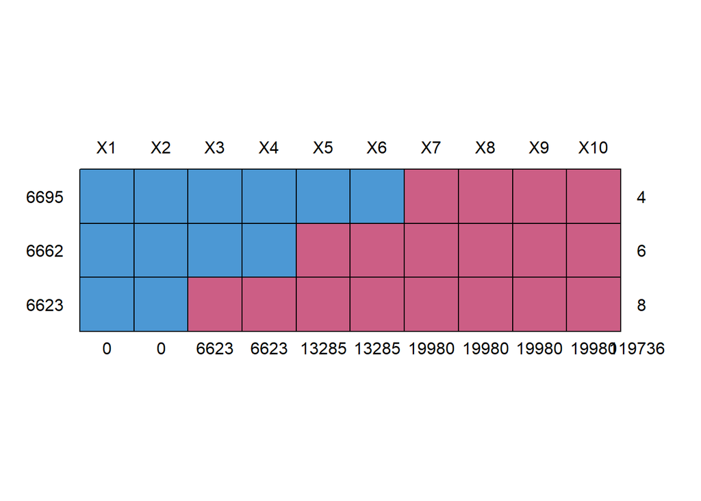

# 3 Estimands

We calculate the absolute outcome risk for each individual observation (i.e. patient) according to five different strategies for dealing with missing values, and three different prediction models.

# 4 Methods

Sidenote for strategy 3: Random forests are very susceptible to variations in the calibration slope, even in contexts without missingness. With huge devsets (i.e., `n_obs > 1.000.000`) or average performance across simulation repetitions, this problem fades. But we’ll need to specifically check the calibration of the random forest models just to be sure!

The five methods for dealing with missing values are:

- (Only for strategy 1 and 3): Missing values are imputed by their conditional mean.[^4]
- (Only for strategy 1 and 3): Missing values are imputed by a random draw from their conditional multivariate distribution.
- (Only for strategy 1 and 3): Missing values are imputed 50 times by a random draw from their distribution. The resulting 50 absolute risk predictions are then averaged to obtain the final prediction.
- (Only for strategy 2): The appropriate pattern submodel is selected for calculating an absolute risk.
- (Only for strategy 3): Missing values are handled using the surrogate splits.

For the first three missing data methods, we need to impute the missing values. The other two do not require this extra step.

```r
# for the imputation methods, we need to fill in the missing values in the validation data
valset %>% glimpse()
```

```
## Rows: 19,980
## Columns: 13
## $ p_miss <dbl> 4, 6, 4, 4, 4, 8, 4, 6, 6, 4, 6, 6, 6, 6, 4, 8, 4, 8, 4, 6, 4, ~
## $ Y_prob <dbl> 0.0233329884, 0.7701213742, 0.4082869926, 0.0567437571, 0.00167~
## $ Y      <int> 0, 1, 0, 0, 0, 0, 0, 0, 0, 0, 0, 0, 0, 0, 0, 0, 0, 0, 0, 0, 0, ~
## $ X1     <dbl> -0.45186427, 0.10846987, 0.09672689, -1.08789532, 2.02306620, -~
## $ X2     <dbl> 0.40285945, 0.64558785, 0.24153144, -0.80106328, -0.36128050, 0~
## $ X3     <dbl> 0.74671550, 0.08128490, -0.39901454, 0.17346685, -2.10821276, N~
## $ X4     <dbl> 0.20203417, 1.53625691, -0.71090337, 0.01023108, -1.94618567, N~
## $ X5     <dbl> -0.76140418, NA, 0.99130161, 0.55770158, 2.53817589, NA, -0.245~
## $ X6     <dbl> -0.435163746, NA, 0.163262862, -0.718541874, 0.489768407, NA, -~
## $ X7     <dbl> NA, NA, NA, NA, NA, NA, NA, NA, NA, NA, NA, NA, NA, NA, NA, NA,~
## $ X8     <dbl> NA, NA, NA, NA, NA, NA, NA, NA, NA, NA, NA, NA, NA, NA, NA, NA,~
## $ X9     <dbl> NA, NA, NA, NA, NA, NA, NA, NA, NA, NA, NA, NA, NA, NA, NA, NA,~
## $ X10    <dbl> NA, NA, NA, NA, NA, NA, NA, NA, NA, NA, NA, NA, NA, NA, NA, NA,~
```

```r
# for evaluation purposes, this includes the outcome (Y = observed outcome; Y_prob = hypothetical probability of the outcome) and the number of missing predictor values

# impute the data, split by number of missing variables for computational efficiency
imp_all <- purrr::map(c(4,6,8), ~comp_cond(devset[,-c(1:2)], valset[,-c(2:3)], m = 51, p = .x))
# TODO: set number of imputations to 51 in actual simulation
```

Now we can generate predictions for each of the cases in the validation set.

```r
# predict Y using the box of submodels method
Y_pred_sub <- pred_sub(valset[,-c(2:3)], mod_sub_2, mod_sub_4, mod_sub_6)

# predict Y using random forest with surrogate splits (switched off because of computational load)
Y_pred_rf_sur <- rep(0, nrow(valset))
# TODO: uncomment this part in actual simulation
# Y_pred_rf_imp <- pred_rf_imp(valset[,-c(1:2)], mod_rf_imp$mod)
# Y_pred_rf_sur <- predict(mod_rf_sur$mod, newdata = valset[,-c(1,2)])
# saveRDS(Y_pred_rf_sur, file = "Data/rf_sur.RDS")
# readRDS("Data/rf_sur.RDS")

# predict Y using the imputation methods icw glm and random forest models
Y_pred_mean <- suppressWarnings(pred_mean(imp_all, mod_true))
Y_pred_draw <- suppressWarnings(pred_draw(imp_all, mod_true))
# TODO: add prediction using random forest
```

Note for the placeholder data (always predict Y = 0) is that there is no discrimination whatsoever.

# 5 Performance measures

List all performance measures to be estimated, justifying their relevance to estimands or other targets.

We evaluate the predicted outcome risk against the original outcome risk (i.e. the absolute outcome risk that would be obtained if we have no missing values). Calculate:

- Root mean square prediction error;
- Brier score (predicted risk vs observed outcome).

Finally, across all hold-out patients:

- Calibration of (predicted Y | one or more missing predictor values) versus (predicted Y | original predictor values) –> calibration slope (voor methode 1 underfitting and slope > 1?);
- Discrimination of (predicted Y | one or more missing predictor values) versus (predicted Y | original predictor values);
- Visual inspection of calibration plot (see plot Gary Collins in Stat med paper, min 100 events).

TODO: Add **MAPE, RMSPE, mean absolute distance wrt real prob., think about AIC and calibration intercept and calibration slope on population level while we’re interested in individual level.**

TODO: add real intercept (this one is re-estimated) using logistic model (en met offset eromheen voor intercept).

root mean sq distance van log calib slope (ideaal is 0, dus verder is slechter). bijv van lasso hele hoge variantie terwijl gem perfect is.

```r
# combine the predictions from the different methods
pred_list <- list(Y_prob = valset$Y_prob,
                  Y_obs = valset$Y,
                  Y_sub = Y_pred_sub,
                  Y_rf_sur = Y_pred_rf_sur,
                  Y_imp_mean = Y_pred_mean,
                  Y_imp_sing = Y_pred_draw$sing,
                  Y_imp_mult = Y_pred_draw$mult)
# RMSE
(RMSE_obs <- purrr::map(pred_list, ~ calc_RMSE(pred = ., obs = pred_list[["Y_obs"]])))
```

```
## $Y_prob
## [1] 0.2842995
##
## $Y_obs
## [1] 0
##
## $Y_sub
## [1] 0.3657138
##
## $Y_rf_sur
## [1] 0.4113626
##
## $Y_imp_mean
## [1] 0.3672204
##
## $Y_imp_sing
## [1] 0.3823421
##
## $Y_imp_mult
## [1] 0.3657867
```

```r
(RMSE_prob <- purrr::map(pred_list, ~ calc_RMSE(pred = ., obs = pred_list[["Y_prob"]])))
```

```
## $Y_prob
## [1] 0
##
## $Y_obs
## [1] 0.2842995
##
## $Y_sub
## [1] 0.2276631
##
## $Y_rf_sur
## [1] 0.2932053
##
## $Y_imp_mean
## [1] 0.2294892
##
## $Y_imp_sing
## [1] 0.2516286
##
## $Y_imp_mult
## [1] 0.2282076
```

```r
# brier score
# (brier_obs <- purrr::map(pred_list, ~ calc_brier(pred = ., obs = valset[, "Y_obs"])))
(brier_prob <- purrr::map(pred_list, ~ calc_brier(pred = ., obs = pred_list[["Y_prob"]])))
```

```
## $Y_prob
## [1] 0
##
## $Y_obs
## [1] 0.0808262
##
## $Y_sub
## [1] 0.05183047
##
## $Y_rf_sur
## [1] 0.08596932
##
## $Y_imp_mean
## [1] 0.05266528
##
## $Y_imp_sing
## [1] 0.06331697
##
## $Y_imp_mult
## [1] 0.05207872
```

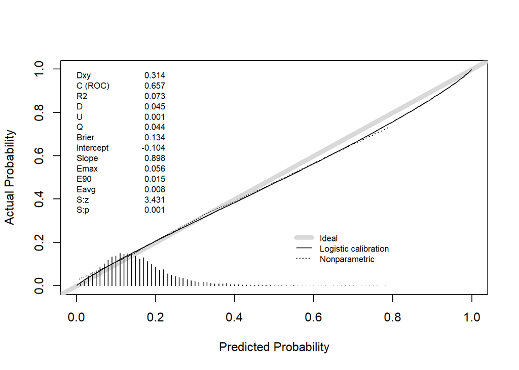

```
##           Dxy       C (ROC)            R2             D      D:Chi-sq
##  3.138947e-01  6.569473e-01  7.322717e-02  4.466554e-02  8.934175e+02
##           D:p             U      U:Chi-sq           U:p             Q
##            NA  8.002012e-04  1.798802e+01  1.241512e-04  4.386534e-02
##         Brier     Intercept         Slope          Emax           E90
##  1.337466e-01 -1.039826e-01  8.978725e-01  5.649124e-02  1.495559e-02
##          Eavg           S:z           S:p
##  8.123790e-03  3.430942e+00  6.014884e-04
```

```r
# Let op: Komt de kans richting het gemiddelde? Zie prestatie van 'methode' met alleen 0en als predicted prob invullen.

rms::val.prob(p = Y_pred_sub, y = valset$Y)
```

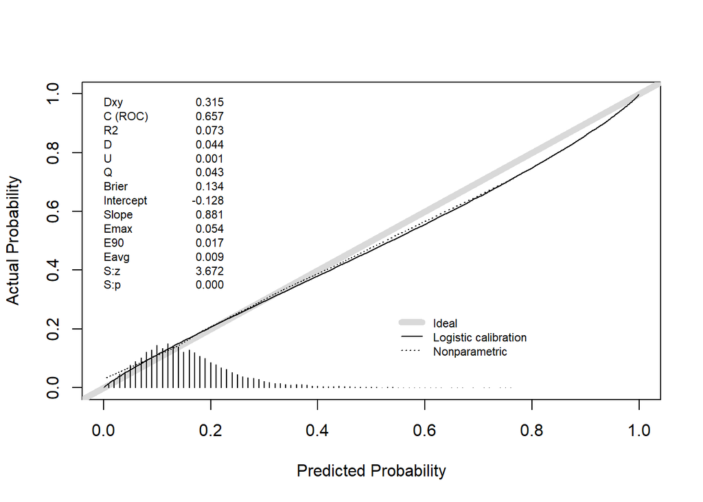

```
##           Dxy       C (ROC)            R2             D      D:Chi-sq
##  3.148758e-01  6.574379e-01  7.265626e-02  4.430907e-02  8.862952e+02
##           D:p             U      U:Chi-sq           U:p             Q
##            NA  1.036705e-03  2.271338e+01  1.169104e-05  4.327236e-02
##         Brier     Intercept         Slope          Emax           E90
##  1.337999e-01 -1.279836e-01  8.809586e-01  5.356858e-02  1.743137e-02
##          Eavg           S:z           S:p
##  8.550790e-03  3.672326e+00  2.403524e-04
```

```r
rms::val.prob(p = Y_pred_draw$mult, y = valset$Y)
```

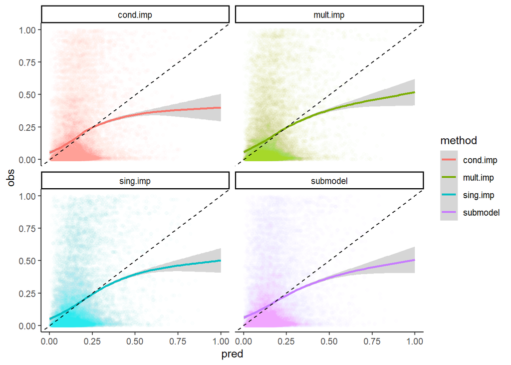

```r
# plot calibration
plotdat <- data.frame(obs = rep(pred_list$Y_prob,4), pred = c(pred_list$Y_sub, pred_list$Y_imp_mean, pred_list$Y_imp_sing, pred_list$Y_imp_mult), method = c("submodel", "cond.imp", "sing.imp", "mult.imp"))
ggplot(plotdat, aes(x = pred, y = obs, color = method)) +
  geom_point(alpha = 0.01) +
  geom_smooth(fullrange = T) +
  geom_abline(intercept = 0, slope = 1, linetype = "dashed") +
  facet_wrap(~method) +
  theme_classic() +
  lims(x = c(0,1), y = c(0,1))
```

[^1]: Note. Potentially add dichotomous predictor(s) later.
[^2]: Note. Maybe add more variance-covariance matrices for sensitivity analyses later. E.g., add one with 200 predictors.
[^3]: check definition, use package `RCS`
[^4]: What to do with categorical predictors? Make dummy variables for each level? See Nijman et al paper!